# Homework 2

**Due Date:** 2022-10-16 at 8:30 AM PT

**Name:** Joseph Matveyenko

**Date:** 2024-10-23

For this assignment, you will practice downloadings, cleaning, and analyzing data from the [National Risk Index (NRI)](https://hazards.fema.gov/nri/) and the [CDC Social Vulnerability Index (SVI)](https://www.atsdr.cdc.gov/placeandhealth/svi/index.html).

## Preparation

1. Create a ‘data’ folder in the root directory of your repository.
2. Inside the ‘data’ folder, create a ‘raw’ folder.
3. Add and commit a ‘.gitignore’ file to the root directory of this repository that excludes all contents of the ‘data’ folder.
4. Download the county-level NRI and SVI data for the entire United States. Place the data in the ‘data/raw’ folder.
5. In the repository README, provide a brief (1-2 sentence) description of each file in the ‘data’ folder and a link to the original source of the data.

## Task 1 - NRI Data Cleaning

**1. Import the NRI data. Ensure that the [FIPS code](https://en.wikipedia.org/wiki/Federal_Information_Processing_Standard_state_code) variable (‘STCOFIPS’) is correctly identified as a string / character variable. Otherwise, the leading zeros will be removed.**

```julia
using DataFrames
using CSV

# change working dir
cd(dirname(pwd()))

# ensure that 'STCOFIPS' is identified as a string
column_types = Dict(:STCOFIPS => String)

# import NRI CSV data
nri_dat = CSV.read("data/raw/NRI_Table_Counties.csv", types=column_types, DataFrame)
first(nri_dat, 3)
```

3×465 DataFrame

365 columns omitted

| Row | OID_ Int64 | NRI_ID String7 | STATE String31 | STATEABBRV String3 | STATEFIPS Int64 | COUNTY String31 | COUNTYTYPE String31? | COUNTYFIPS Int64 | STCOFIPS String | POPULATION Int64 | BUILDVALUE Float64 | AGRIVALUE Float64 | AREA Float64 | RISK_VALUE Float64? | RISK_SCORE Float64? | RISK_RATNG String31 | RISK_SPCTL Float64? | EAL_SCORE Float64 | EAL_RATNG String31 | EAL_SPCTL Float64 | EAL_VALT Float64 | EAL_VALB Float64 | EAL_VALP Float64 | EAL_VALPE Float64 | EAL_VALA Float64 | ALR_VALB Float64 | ALR_VALP Float64 | ALR_VALA Float64 | ALR_NPCTL Float64 | … |
| --- | --- | --- | --- | --- | --- | --- | --- | --- | --- | --- | --- | --- | --- | --- | --- | --- | --- | --- | --- | --- | --- | --- | --- | --- | --- | --- | --- | --- | --- | --- |
| 1 | 1 | C01001 | Alabama | AL | 1 | Autauga | County | 1 | 01001 | 58764 | 9.12327e9 | 2.4614e7 | 610.471 | 6.15605e6 | 49.2205 | Relatively Low | 34.3284 | 50.944 | Very Low | 40.2985 | 5.51405e6 | 2.81669e6 | 0.226414 | 2.6264e6 | 70954.3 | 0.000308737 | 3.85294e-6 | 0.00288268 | 21.3866 | … |
| 2 | 2 | C01003 | Alabama | AL | 1 | Baldwin | County | 3 | 01003 | 231365 | 4.59685e10 | 1.38089e8 | 2047.74 | 2.10633e8 | 97.7092 | Relatively High | 98.5075 | 98.2358 | Relatively High | 98.5075 | 2.02015e8 | 1.82788e8 | 1.48318 | 1.72049e7 | 2.02207e6 | 0.00397638 | 6.41058e-6 | 0.0146432 | 94.5528 | … |
| 3 | 3 | C01005 | Alabama | AL | 1 | Barbour | County | 5 | 01005 | 25160 | 4.8477e9 | 1.21076e8 | 913.647 | 7.41284e6 | 56.1884 | Relatively Low | 41.791 | 44.8777 | Very Low | 37.3134 | 4.7153e6 | 2.34467e6 | 0.148954 | 1.72787e6 | 6.42763e5 | 0.000483667 | 5.92028e-6 | 0.00530876 | 42.0613 | … |

**2. Subset the NRI data to include only the 5-digit state/county FIPS code and all colums ending with ‘_AFREQ’ and ‘_RISKR’. Each of these columns represents a different hazard type.**

```julia
# string endings
str_ends = ["_AFREQ", "_RISKR"]

# get columns to include
include_cols = ["STCOFIPS"; [i for i in names(nri_dat) if any(endswith(i, str) for str in str_ends)]]

#subsetting dataframe
nri_dat_subset = nri_dat[:, include_cols]
first(nri_dat_subset, 3)
```

3×37 DataFrame

| Row | STCOFIPS String | AVLN_AFREQ Float64? | AVLN_RISKR String31 | CFLD_AFREQ Float64? | CFLD_RISKR String31 | CWAV_AFREQ Float64 | CWAV_RISKR String31 | DRGT_AFREQ Float64? | DRGT_RISKR String31 | ERQK_AFREQ Float64 | ERQK_RISKR String31 | HAIL_AFREQ Float64? | HAIL_RISKR String31 | HWAV_AFREQ Float64 | HWAV_RISKR String31 | HRCN_AFREQ Float64? | HRCN_RISKR String31 | ISTM_AFREQ Float64? | ISTM_RISKR String31 | LNDS_AFREQ Float64? | LNDS_RISKR String31 | LTNG_AFREQ Float64? | LTNG_RISKR String31 | RFLD_AFREQ Float64 | RFLD_RISKR String31 | SWND_AFREQ Float64? | SWND_RISKR String31 | TRND_AFREQ Float64? | TRND_RISKR String31 | … |
| --- | --- | --- | --- | --- | --- | --- | --- | --- | --- | --- | --- | --- | --- | --- | --- | --- | --- | --- | --- | --- | --- | --- | --- | --- | --- | --- | --- | --- | --- | --- |
| 1 | 01001 | missing | Not Applicable | missing | Not Applicable | 0.0 | No Rating | 25.9698 | Relatively Low | 0.000431448 | Very Low | 2.80676 | Relatively Low | 0.371517 | Relatively Moderate | 0.0804504 | Relatively Low | 0.402025 | Very Low | 0.01 | Relatively Low | 78.9381 | Relatively Low | 1.08333 | Relatively Low | 1.29731 | Relatively Low | 0.480184 | Relatively Moderate | … |
| 2 | 01003 | missing | Not Applicable | 3.68414 | Relatively Low | 0.0 | No Rating | 12.3534 | Relatively Moderate | 0.000337736 | Relatively Low | 1.52926 | Relatively Low | 0.939761 | Relatively Moderate | 0.248233 | Relatively High | 0.191996 | Relatively Low | 0.0105603 | Relatively Low | 142.232 | Very High | 2.70833 | Relatively Moderate | 1.83903 | Relatively Low | 0.95314 | Relatively Moderate | … |
| 3 | 01005 | missing | Not Applicable | missing | Not Applicable | 0.0 | No Rating | 43.957 | Relatively Low | 0.000227048 | Very Low | 1.90879 | Very Low | 0.371517 | Relatively Low | 0.116398 | Relatively Low | 0.393288 | Very Low | 0.01 | Relatively Low | 74.6551 | Relatively Moderate | 0.25 | Very Low | 1.45648 | Relatively Low | 0.739018 | Relatively Moderate | … |

**3. Create a table / dataframe that, for each hazard type, shows the number of missing values in the ‘_AFREQ’ and ‘_RISKR’ columns.**

```julia
# function to count missing values
function count_missing(df)
    return DataFrame(Column = names(df), MissingCount = [sum(ismissing, df[:, col]) for col in names(df)])
end

# create new dataframe by counting missing values
nri_dat_missing = count_missing(nri_dat_subset[:, 2:end])
first(nri_dat_missing, 5)
```

5×2 DataFrame

| Row | Column String | MissingCount Int64 |
| --- | --- | --- |
| 1 | AVLN_AFREQ | 3023 |
| 2 | AVLN_RISKR | 0 |
| 3 | CFLD_AFREQ | 2646 |
| 4 | CFLD_RISKR | 0 |
| 5 | CWAV_AFREQ | 0 |

**4. Create a new column in the original data table indicating whether or not ‘AVLN_AFREQ’ is missing or observed. Show the cross-tabulation of the ‘AVLN_AFREQ’ missingness and ‘AVLN_RISKR’ columns (including missing values). What do you observe?**

```julia
using FreqTables

# create column AVLN_MISS that = 1 when AVLN_AFREQ missing
transform!(nri_dat_subset, :AVLN_AFREQ => ByRow(ismissing) => :AVLN_MISS)

# cross tabulation of AVLN_MISS and AVLN_RISK
freqtable(nri_dat_subset.AVLN_RISKR, nri_dat_subset.AVLN_MISS)
```

```
6×2 Named Matrix{Int64}
        Dim1 ╲ Dim2 │ false   true
────────────────────┼─────────────
Not Applicable      │     0   3023
Relatively High     │    15      0
Relatively Low      │    52      0
Relatively Moderate │    33      0
Very High           │     9      0
Very Low            │    99      0
```

We observe that all instances when the variable `AVLN_AFREQ` is missing, `AVLN_RISKR` is coded as ‘Not Applicable’.

**5. Assuming that a risk that is “not applicable” to a county has an annualized frequency of 0, impute the relevant missing values in the ‘_AFREQ’ columns with 0.**

```julia
# list of variables for which to impute missing values
imp_vars = [col for col in names(nri_dat_subset) if endswith(col, "_AFREQ")]
risk_vars = [col for col in names(nri_dat_subset) if endswith(col, "_RISKR")]
new_vars = [i * "_IMP" for i in imp_vars]


# assuming that NA means the freq is 0, imput missing values
impute_missing(x, y) = ifelse.(y .== "Not Applicable" .&& ismissing.(x), 0, x)

for (iv, rv, nv) in zip(imp_vars, risk_vars, new_vars)
    transform!(nri_dat_subset, [Symbol(iv), Symbol(rv)] => impute_missing => Symbol(nv))
end

first(nri_dat_subset, 10)
```

10×56 DataFrame

| Row | STCOFIPS String | AVLN_AFREQ Float64? | AVLN_RISKR String31 | CFLD_AFREQ Float64? | CFLD_RISKR String31 | CWAV_AFREQ Float64 | CWAV_RISKR String31 | DRGT_AFREQ Float64? | DRGT_RISKR String31 | ERQK_AFREQ Float64 | ERQK_RISKR String31 | HAIL_AFREQ Float64? | HAIL_RISKR String31 | HWAV_AFREQ Float64 | HWAV_RISKR String31 | HRCN_AFREQ Float64? | HRCN_RISKR String31 | ISTM_AFREQ Float64? | ISTM_RISKR String31 | LNDS_AFREQ Float64? | LNDS_RISKR String31 | LTNG_AFREQ Float64? | LTNG_RISKR String31 | RFLD_AFREQ Float64 | RFLD_RISKR String31 | SWND_AFREQ Float64? | SWND_RISKR String31 | TRND_AFREQ Float64? | TRND_RISKR String31 | … |
| --- | --- | --- | --- | --- | --- | --- | --- | --- | --- | --- | --- | --- | --- | --- | --- | --- | --- | --- | --- | --- | --- | --- | --- | --- | --- | --- | --- | --- | --- | --- |
| 1 | 01001 | missing | Not Applicable | missing | Not Applicable | 0.0 | No Rating | 25.9698 | Relatively Low | 0.000431448 | Very Low | 2.80676 | Relatively Low | 0.371517 | Relatively Moderate | 0.0804504 | Relatively Low | 0.402025 | Very Low | 0.01 | Relatively Low | 78.9381 | Relatively Low | 1.08333 | Relatively Low | 1.29731 | Relatively Low | 0.480184 | Relatively Moderate | … |
| 2 | 01003 | missing | Not Applicable | 3.68414 | Relatively Low | 0.0 | No Rating | 12.3534 | Relatively Moderate | 0.000337736 | Relatively Low | 1.52926 | Relatively Low | 0.939761 | Relatively Moderate | 0.248233 | Relatively High | 0.191996 | Relatively Low | 0.0105603 | Relatively Low | 142.232 | Very High | 2.70833 | Relatively Moderate | 1.83903 | Relatively Low | 0.95314 | Relatively Moderate | … |
| 3 | 01005 | missing | Not Applicable | missing | Not Applicable | 0.0 | No Rating | 43.957 | Relatively Low | 0.000227048 | Very Low | 1.90879 | Very Low | 0.371517 | Relatively Low | 0.116398 | Relatively Low | 0.393288 | Very Low | 0.01 | Relatively Low | 74.6551 | Relatively Moderate | 0.25 | Very Low | 1.45648 | Relatively Low | 0.739018 | Relatively Moderate | … |
| 4 | 01007 | missing | Not Applicable | missing | Not Applicable | 0.0 | No Rating | 28.8945 | Very Low | 0.000790238 | Very Low | 3.44787 | Very Low | 0.371517 | Relatively Low | 0.0667239 | Very Low | 0.413094 | Relatively Low | 0.01 | Relatively Low | 84.589 | Relatively Low | 0.666667 | Very Low | 1.45758 | Relatively Low | 0.58616 | Relatively Moderate | … |
| 5 | 01009 | missing | Not Applicable | missing | Not Applicable | 0.0 | No Rating | 28.1526 | Relatively Low | 0.000816916 | Relatively Low | 5.10134 | Very Low | 0.371517 | Relatively Moderate | 0.0392382 | Very Low | 0.509665 | Relatively Moderate | 0.01 | Relatively Low | 88.7777 | Relatively Moderate | 1.16667 | Very Low | 4.28676 | Relatively Moderate | 0.710332 | Relatively Moderate | … |
| 6 | 01011 | missing | Not Applicable | missing | Not Applicable | 0.0 | No Rating | 42.7089 | Relatively Moderate | 0.000402969 | Very Low | 2.34483 | Very Low | 0.371517 | Relatively Low | 0.123758 | Relatively Low | 0.493817 | Very Low | 0.01 | Relatively Low | 72.0622 | Relatively Low | 0.333333 | Very Low | 1.51452 | Very Low | 0.557943 | Relatively Low | … |
| 7 | 01013 | missing | Not Applicable | missing | Not Applicable | 0.0 | No Rating | 20.6616 | Relatively Low | 0.000370853 | Very Low | 1.744 | Very Low | 0.495356 | Relatively Low | 0.12474 | Relatively Low | 0.229933 | Very Low | 0.01 | Relatively Low | 85.6841 | Relatively Moderate | 0.5 | Very Low | 1.6823 | Relatively Low | 0.579694 | Relatively Low | … |
| 8 | 01015 | missing | Not Applicable | missing | Not Applicable | 0.0 | No Rating | 29.342 | Very Low | 0.000740531 | Relatively Low | 5.16843 | Relatively Low | 0.309598 | Relatively Moderate | 0.0406642 | Relatively Low | 0.280711 | Very Low | 0.0105626 | Relatively Moderate | 88.2116 | Relatively Moderate | 1.0 | Relatively Low | 2.78403 | Relatively Moderate | 0.497338 | Relatively High | … |
| 9 | 01017 | missing | Not Applicable | missing | Not Applicable | 0.0 | No Rating | 57.9356 | Very Low | 0.000447361 | Very Low | 3.82391 | Very Low | 0.371517 | Relatively Moderate | 0.0889289 | Relatively Low | 0.515827 | Relatively Low | 0.01 | Relatively Low | 61.6933 | Relatively Low | 0.75 | Relatively Low | 1.18236 | Relatively Low | 0.436673 | Relatively Low | … |
| 10 | 01019 | missing | Not Applicable | missing | Not Applicable | 0.0 | No Rating | 30.6298 | Relatively Low | 0.0010977 | Relatively Low | 5.34745 | Very Low | 0.309598 | Relatively Low | 0.0320731 | Very Low | 0.421406 | Relatively Low | 0.01 | Relatively Low | 77.2466 | Relatively Low | 0.791667 | Relatively Low | 2.94614 | Relatively Low | 0.442735 | Relatively Moderate | … |

## Task 2 - SVI Data Cleaning

**1. Import the SVI data. Ensure that the FIPS code is correctly identified as a string / character variable. Otherwise, the leading zeros will be removed.** **1. Subset the SVI data to include only the following columns:** `ST, STATE, ST_ABBR, STCNTY, COUNTY, FIPS, LOCATION, AREA_SQMI, E_TOTPOP, EP_POV150, EP_UNEMP, EP_HBURD, EP_NOHSDP, EP_UNINSUR, EP_AGE65, EP_AGE17, EP_DISABL, EP_SNGPNT, EP_LIMENG, EP_MINRTY, EP_MUNIT, EP_MOBILE, EP_CROWD, EP_NOVEH, EP_GROUPQ, EP_NOINT, EP_AFAM, EP_HISP, EP_ASIAN, EP_AIAN, EP_NHPI, EP_TWOMORE, EP_OTHERRACE`

```julia
# ensure that 'FIPS' is identified as a string
column_types = Dict(:FIPS => String)

# import SVI CSV data
svi_dat = CSV.read("data/raw/SVI_2022_US_county.csv", types=column_types, DataFrame)

# subset data to include given columns
given_columns_str = "ST, STATE, ST_ABBR, STCNTY, COUNTY, FIPS, LOCATION, AREA_SQMI, E_TOTPOP, EP_POV150, EP_UNEMP, EP_HBURD, EP_NOHSDP, EP_UNINSUR, EP_AGE65, EP_AGE17, EP_DISABL, EP_SNGPNT, EP_LIMENG, EP_MINRTY, EP_MUNIT, EP_MOBILE, EP_CROWD, EP_NOVEH, EP_GROUPQ, EP_NOINT, EP_AFAM, EP_HISP, EP_ASIAN, EP_AIAN, EP_NHPI, EP_TWOMORE, EP_OTHERRACE"
given_columns = strip.(split(given_columns_str, ","))
svi_dat_subset = svi_dat[:, given_columns]
first(svi_dat, 3)
```

3×158 DataFrame

58 columns omitted

| Row | ST Int64 | STATE String31 | ST_ABBR String3 | STCNTY Int64 | COUNTY String | FIPS String | LOCATION String | AREA_SQMI Float64 | E_TOTPOP Int64 | M_TOTPOP Int64 | E_HU Int64 | M_HU Int64 | E_HH Int64 | M_HH Int64 | E_POV150 Int64 | M_POV150 Int64 | E_UNEMP Int64 | M_UNEMP Int64 | E_HBURD Int64 | M_HBURD Int64 | E_NOHSDP Int64 | M_NOHSDP Int64 | E_UNINSUR Int64 | M_UNINSUR Int64 | E_AGE65 Int64 | M_AGE65 Int64 | E_AGE17 Int64 | M_AGE17 Int64 | E_DISABL Int64 | … |
| --- | --- | --- | --- | --- | --- | --- | --- | --- | --- | --- | --- | --- | --- | --- | --- | --- | --- | --- | --- | --- | --- | --- | --- | --- | --- | --- | --- | --- | --- | --- |
| 1 | 1 | Alabama | AL | 1001 | Autauga County | 01001 | Autauga County, Alabama | 594.455 | 58761 | 0 | 24457 | 41 | 22308 | 369 | 11780 | 1363 | 752 | 215 | 4389 | 582 | 3857 | 512 | 4225 | 753 | 9176 | 98 | 13766 | 42 | 9425 | … |
| 2 | 1 | Alabama | AL | 1003 | Baldwin County | 01003 | Baldwin County, Alabama | 1589.86 | 233420 | 0 | 125113 | 85 | 90802 | 1229 | 42088 | 2875 | 3825 | 609 | 21039 | 1527 | 14031 | 1216 | 21472 | 1920 | 49499 | 64 | 49396 | 0 | 31878 | … |
| 3 | 1 | Alabama | AL | 1005 | Barbour County | 01005 | Barbour County, Alabama | 885.008 | 24877 | 0 | 11673 | 52 | 9016 | 304 | 8248 | 594 | 516 | 162 | 2260 | 321 | 4155 | 360 | 2348 | 318 | 4926 | 28 | 5151 | 26 | 3970 | … |

**2. Create a table / dataframe that shows the number of missing values in each column. (Hint: if you wrote a function for Task 1, you can reuse it here.)**

```julia
# reusing the function from part 1 to count missing values
svi_dat_missing = count_missing(svi_dat_subset)
first(svi_dat_missing, 5)
```

5×2 DataFrame

| Row | Column String | MissingCount Int64 |
| --- | --- | --- |
| 1 | ST | 0 |
| 2 | STATE | 0 |
| 3 | ST_ABBR | 0 |
| 4 | STCNTY | 0 |
| 5 | COUNTY | 0 |

## Task 3 - Data Merging

**1. Identify any FIPS codes that are present in the NRI data but not in the SVI data and vice versa. Describe any discrepancies and possible causes? What to these discrepancies, if any, mean for interpreting results based on the merged dataset moving forward?**

```julia
# identify unique FIPS codes in both datasets
nri_fips = unique(nri_dat_subset.STCOFIPS)
svi_fips = unique(svi_dat_subset.FIPS)

# identify FIPS codes in NRI but not in SVI
nri_not_in_svi = setdiff(nri_fips, svi_fips)
println("In NRI but not in SVI: $nri_not_in_svi")

# identify FIPS codes in SVI but not in NRI
svi_not_in_nri = setdiff(svi_fips, nri_fips)
println("In SVI but not in NRI: $svi_not_in_nri")
```

```
In NRI but not in SVI: ["09001", "09003", "09005", "09007", "09009", "09011", "09013", "09015", "60010", "60020", "60050", "66010", "69100", "69110", "69120", "72001", "72003", "72005", "72007", "72009", "72011", "72013", "72015", "72017", "72019", "72021", "72023", "72025", "72027", "72029", "72031…
In SVI but not in NRI: ["09110", "09120", "09130", "09140", "09150", "09160", "09170", "09180", "09190"]
```

There are discrepancies in the FIPS codes for Connecticut; both the NRI and SVI data contains data on Connecticut but may be using different FIPS code variants to represent the same counties. Additionally, the NRI data includes FIPS codes for American Somoa, Guam, the Northern Mariana Islands, Puerto Rico, and U.S. Virgin Islands, which are not present in the SVI data set. These discrepancies mean that it will likely not be possible to gain insight on the U.S. territories not covered in the SVI data through merging the two data sets. Further, the CT discrepancies should be reconciled prior to analysis.

**2. Merge the NRI and SVI data on the FIPS code. Use an outer join to keep all counties in the final dataset.**

```julia
# merging both datasets
merged_nri_svi = outerjoin(nri_dat_subset, svi_dat_subset, on = :STCOFIPS => :FIPS)
first(merged_nri_svi, 5)
```

5×88 DataFrame

| Row | STCOFIPS String | AVLN_AFREQ Float64? | AVLN_RISKR String31? | CFLD_AFREQ Float64? | CFLD_RISKR String31? | CWAV_AFREQ Float64? | CWAV_RISKR String31? | DRGT_AFREQ Float64? | DRGT_RISKR String31? | ERQK_AFREQ Float64? | ERQK_RISKR String31? | HAIL_AFREQ Float64? | HAIL_RISKR String31? | HWAV_AFREQ Float64? | HWAV_RISKR String31? | HRCN_AFREQ Float64? | HRCN_RISKR String31? | ISTM_AFREQ Float64? | ISTM_RISKR String31? | LNDS_AFREQ Float64? | LNDS_RISKR String31? | LTNG_AFREQ Float64? | LTNG_RISKR String31? | RFLD_AFREQ Float64? | RFLD_RISKR String31? | SWND_AFREQ Float64? | SWND_RISKR String31? | TRND_AFREQ Float64? | TRND_RISKR String31? | … |
| --- | --- | --- | --- | --- | --- | --- | --- | --- | --- | --- | --- | --- | --- | --- | --- | --- | --- | --- | --- | --- | --- | --- | --- | --- | --- | --- | --- | --- | --- | --- |
| 1 | 01001 | missing | Not Applicable | missing | Not Applicable | 0.0 | No Rating | 25.9698 | Relatively Low | 0.000431448 | Very Low | 2.80676 | Relatively Low | 0.371517 | Relatively Moderate | 0.0804504 | Relatively Low | 0.402025 | Very Low | 0.01 | Relatively Low | 78.9381 | Relatively Low | 1.08333 | Relatively Low | 1.29731 | Relatively Low | 0.480184 | Relatively Moderate | … |
| 2 | 01003 | missing | Not Applicable | 3.68414 | Relatively Low | 0.0 | No Rating | 12.3534 | Relatively Moderate | 0.000337736 | Relatively Low | 1.52926 | Relatively Low | 0.939761 | Relatively Moderate | 0.248233 | Relatively High | 0.191996 | Relatively Low | 0.0105603 | Relatively Low | 142.232 | Very High | 2.70833 | Relatively Moderate | 1.83903 | Relatively Low | 0.95314 | Relatively Moderate | … |
| 3 | 01005 | missing | Not Applicable | missing | Not Applicable | 0.0 | No Rating | 43.957 | Relatively Low | 0.000227048 | Very Low | 1.90879 | Very Low | 0.371517 | Relatively Low | 0.116398 | Relatively Low | 0.393288 | Very Low | 0.01 | Relatively Low | 74.6551 | Relatively Moderate | 0.25 | Very Low | 1.45648 | Relatively Low | 0.739018 | Relatively Moderate | … |
| 4 | 01007 | missing | Not Applicable | missing | Not Applicable | 0.0 | No Rating | 28.8945 | Very Low | 0.000790238 | Very Low | 3.44787 | Very Low | 0.371517 | Relatively Low | 0.0667239 | Very Low | 0.413094 | Relatively Low | 0.01 | Relatively Low | 84.589 | Relatively Low | 0.666667 | Very Low | 1.45758 | Relatively Low | 0.58616 | Relatively Moderate | … |
| 5 | 01009 | missing | Not Applicable | missing | Not Applicable | 0.0 | No Rating | 28.1526 | Relatively Low | 0.000816916 | Relatively Low | 5.10134 | Very Low | 0.371517 | Relatively Moderate | 0.0392382 | Very Low | 0.509665 | Relatively Moderate | 0.01 | Relatively Low | 88.7777 | Relatively Moderate | 1.16667 | Very Low | 4.28676 | Relatively Moderate | 0.710332 | Relatively Moderate | … |

**3. Create a table / dataframe that shows the number of missing values in each column of the merged dataset.**

```julia
# reusing the function from part 1 to count missing values
merged_nri_svi_missing = count_missing(merged_nri_svi)
first(merged_nri_svi_missing, 5)
```

5×2 DataFrame

| Row | Column String | MissingCount Int64 |
| --- | --- | --- |
| 1 | STCOFIPS | 0 |
| 2 | AVLN_AFREQ | 3032 |
| 3 | AVLN_RISKR | 9 |
| 4 | CFLD_AFREQ | 2655 |
| 5 | CFLD_RISKR | 9 |

## Task 4 - Data Analysis

**1. For each numerical variable in the merged dataset, plot a histogram showing the distribution of values. (Hint: write a function to make the histogram for a single variable, then use a loop or apply function to make the histograms for all numerical variables.)**

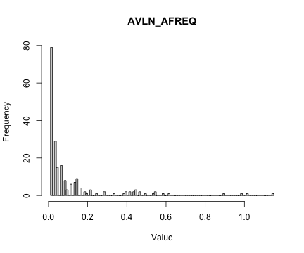

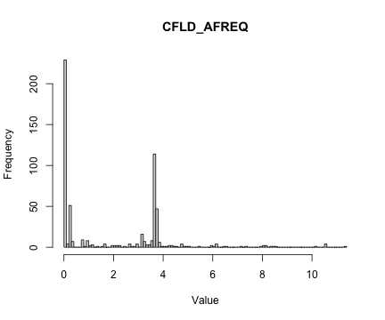

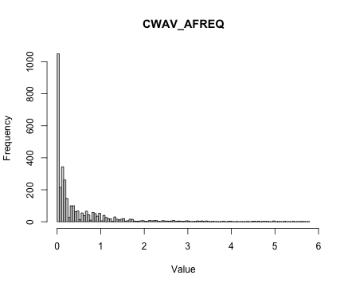

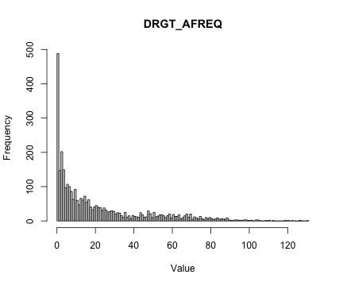

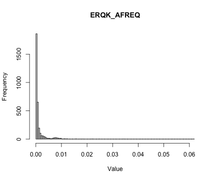

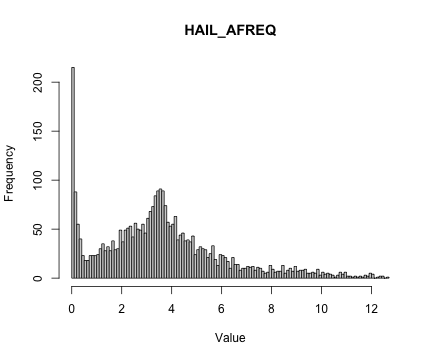

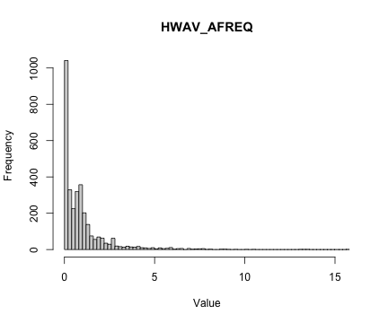

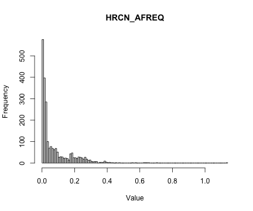

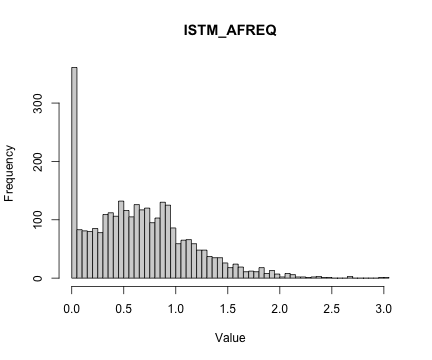

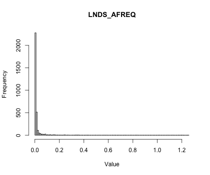

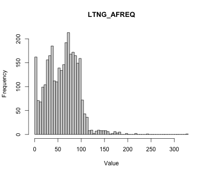

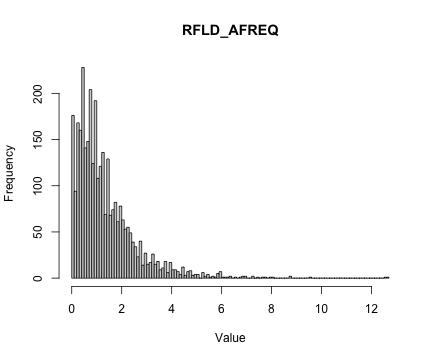

[52 more figures not shown]

```
RObject{NilSxp}
NULL
```

```julia
using Plots
using RCall


# function to make histograms
function plot_hist(x, titles; bins=100)
    R"""
    for (i in 1:length($x)){
        hist(unlist($x[i]), breaks=100, main=$titles[i], xlab='Value')
    }
    """
end

# creating empty arrays for data to plot
plot_data = []
plot_titles = String[]
# iterate through each col of df
for i in names(merged_nri_svi)
    # remove missing values
    clean_col = collect(skipmissing(merged_nri_svi[:,Symbol(i)]))
    # check if numeric
    if eltype(clean_col)<:Number && !isempty(clean_col) && length(unique(clean_col))>5
        # adding data to arrays
        push!(plot_data, [round(x, digits=5) for x in clean_col if x isa Number])
        push!(plot_titles, i)
    end
end

# generating R plots
plot_hist(plot_data, plot_titles)
```